# DATA1001/1901 Topic 7

## Box 1

What we know:

- A box contains the numbers 1, 2, and 3. This is the population.
- We draw 25 times from the box, with replacement. This forms the sample.
- We are interested in the properties of the **sum** of the 25 draws.

How to model in R:

```r
# Step1: Define the box
box <- c(1,2,3)

# Step2: calculate the Mean and SD of the box
mean_box <- mean(box)
# popsd_box <- sqrt((length(box)-1)/length(box) * sd(box))

library(multicon)
popsd_box <- popsd(box)

# Step3: Calculate the EV and SE of the SUM of the sample
ev <- 25 * mean_box
se <- sqrt(25) * popsd_box

# just to present it better:
c(ev,se)
```

```
## [1] 50.000000  4.082483
```

**Question:** Using the appropriate normal approximation/curve, can we estimate the chance that the sum of the sample is between 50 and 55 (inclusive)?

First, work out the standard units, and draw the standard Normal curve. Then, calculate the probability from this curve, tapping on your knowledge of the properties of a Normal curve, or using R.

```r
su1 <- (50-ev)/se
su2 <- (55-ev)/se
pnorm(su2)-pnorm(su1)
```

```
## [1] 0.3896643
```

```r
# Quicker way
pnorm(55,ev,se)-pnorm(50,ev,se)
```

```
## [1] 0.3896643
```

```r
# Adjust your calculation, using the continuity correction?  Why do we use it?
pnorm(49.5,ev,se)-pnorm(55.5,ev,se)
```

```
## [1] -0.4597836
```

## Box 2

- A box contains the numbers 1, 2, 3, 4, 5, and 6. This is the population.
- We draw 16 times from the box, with replacement. This forms the sample.
- We are interested in the properties of the **mean** of the 16 draws.

How to model in R:

```r
# Step1: Define the box
box <- 1:6 # we can use the ":" operator to produce number sequences more easily

# Step2: Calculate the Mean and SD of the box
mean(box)
```

```
## [1] 3.5
```

```r
library(multicon)
popsd(box)
```

```
## [1] 1.707825
```

```r
# Step3: Calculate the EV and SE of the MEAN of the sample
ev <- mean(box)
se <- popsd(box)/sqrt(16)
c(ev,se)
```

```
## [1] 3.5000000 0.4269563
```

# Have a go

For the remainder of the lab, go through the following exercises. **In the code chunks below, remove the options `results='hide'` and `fig.show='hide'` to reveal the code output.**

## Experiment with the CLT

- Experiment with the [Seeing Theory: CLT](https://students.brown.edu/seeing-theory/probability-distributions/index.html) app.
- In your own words, define the CLT in a sentence.

## Think about the CLT

In which of the following scenarios could the CLT be applied to the sample sum or sample mean? Justify your answer.

- We extract samples of size 1 from a symmetric distribution.
- We extract samples of size 30 from a symmetric distribution.(-)
- We extract samples of size 30 from an asymmetric distribution.
- We extract 100 samples from an asymmetric distribution.

## Simulate simple box (symmetric)

Experiment to find out what minimum size number of draws it takes, for the distribution of the sample sum to start looking like a Normal curve.

Method: Use `replicate` to simulate 1000 samples of 10 draws (and then 100 draws) from a 0,1 box, and compare your results.

Take 10 draws from a box with population 0,1 [1000 replicates]

```r
set.seed(1)
box <- c(0, 1)
totals <- replicate(1000, sum(sample(box, 10, rep = TRUE)))
table(totals)
```

```
## totals
##   1   2   3   4   5   6   7   8   9  10
##  10  50 102 222 230 202 138  35   6   5
```

```r
mean(totals)
```

```
## [1] 5.016
```

```r
sd(totals)
```

```
## [1] 1.591313
```

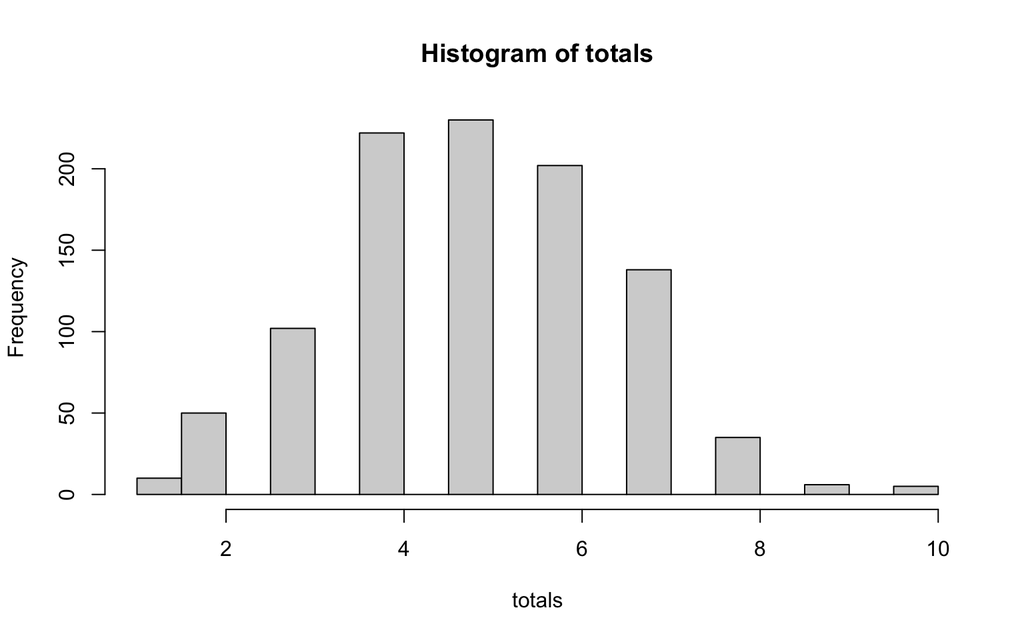

```r
hist(totals, nclass = 20)
```

Take 100 draws from a box with population 0,1 [1000 replicates]

```r
set.seed(1)
box <- c(0,1)
totals <- replicate(1000, sum(sample(box, 100, rep = TRUE)))
table(totals)
```

```
## totals
## 32 34 36 37 38 39 40 41 42 43 44 45 46 47 48 49 50 51 52 53 54 55 56 57 58 59
##  1  1  1  3  2  6 15 16 27 29 51 52 58 64 64 80 68 71 59 72 55 57 54 24 29 17
## 60 61 62 63 64 65 68
##  5  7  4  4  2  1  1
```

```r
mean(totals)
```

```
## [1] 49.987
```

```r
sd(totals)
```

```
## [1] 5.137823
```

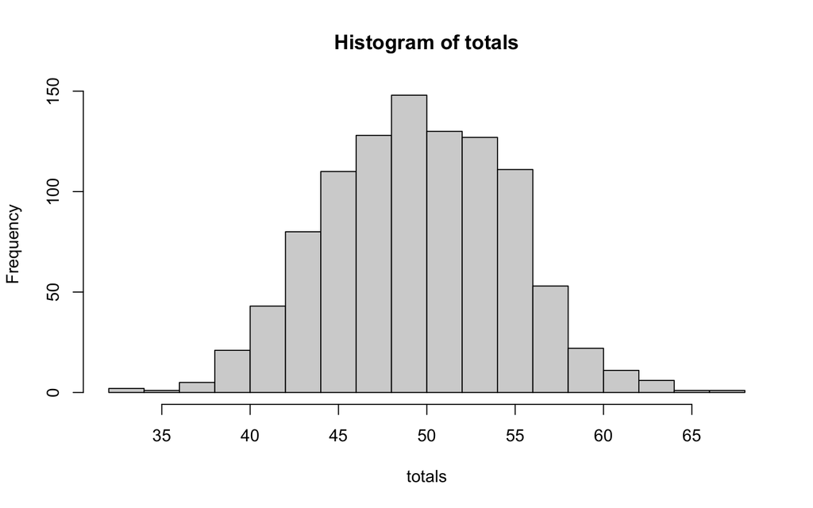

```r
hist(totals, nclass = 20)
```

## Simulate assymetric box

Experiment to find out what minimum size number of draws it takes, for the distribution of the sample sum to start looking like a Normal curve.

Take 10 draws from a box with the population 0,1,1,1,1,1,1 [1000 replicates]

```r
set.seed(1)
box <- c(0,1,1,1,1,1,1)
totals <- replicate(1000, sum(sample(box, 10, rep = TRUE)))
table(totals)
```

```
## totals
##   5   6   7   8   9  10
##   8  38 120 262 357 215
```

```r
mean(totals)
```

```
## [1] 8.567
```

```r
sd(totals)
```

```
## [1] 1.11389
```

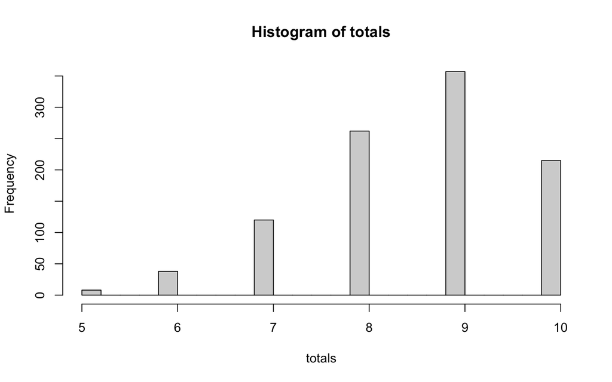

```r
hist(totals, nclass = 20)
```

Take 100 draws from a box with the population 0,1,1,1,1,1,1 [1000 replicates]

```r
set.seed(1)
box <- c(0, rep(1, 6)) # alternative to c(0,1,1,1,1,1,1)
totals <- replicate(1000, sum(sample(box, 100, rep = TRUE)))
table(totals)
```

```
## totals
##  75  76  77  78  79  80  81  82  83  84  85  86  87  88  89  90  91  92  93  94
##   1   2   7  15  17  25  44  63  76 109 103 114 101 105  84  50  46  25   7   5
##  95
##   1
```

```r
mean(totals)
```

```
## [1] 85.737
```

```r
sd(totals)
```

```
## [1] 3.42426
```

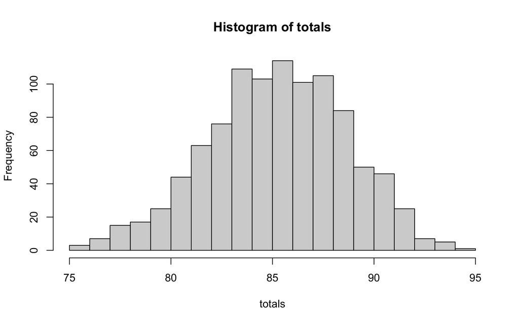

```r
hist(totals, nclass = 20)
```

## Explore – tidyverse

What if we want to use `ggplot2` on a data that is stored as a vector object (i.e. it *isn’t* a **data frame**)? Let’s work it out using the latest `totals` output from the above exercises. Don’t forget to load the `tidyverse`!

```r
library(tidyverse)
```

What type of data is `total`?

```r
str(totals) # we can also use class() if we really want specific information
```

```
##  num [1:1000] 83 86 82 82 84 91 86 84 86 85 ...
```

One way to plot the data is to convert it to a `data.frame` object using `as.data.frame()` or simply `data.frame()`. However, `ggplot()` works well with vectors - just don’t declare a `data =` argument!

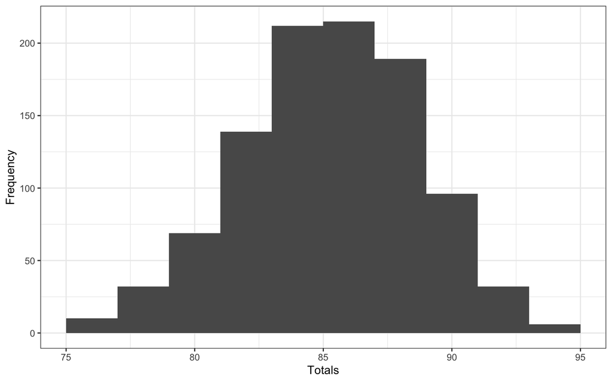

```r
ggplot() +
  geom_histogram(aes(x = totals), binwidth = 2) +
  theme_bw() +
  xlab("Totals") +
  ylab("Frequency")
```